# Can you predict the popularity of a song?

## 0. Introduction

I spend a lot of time listening to music on Spotify (I'm listening to some jams as I write this now). When it comes to my music taste though, I am not much of a trend setter. Occasionally, however, when I look at the number of streams on Spotify of a new song, it surprises me - sometimes with a large number, sometimes with a undeservingly low number. And with this, I wondered if there was a way to predict the popularity of a song. Spotify has over 155 million users and each of their songs are tracked with streams and acoustic variables, making it a great dataset for analyzing music.

This tutorial will walk you through using machine learning to **predict the popularity of a song based on these acoustic variables**, plus a little addition of **creating a recommendation system** with K-nearest-neighbors.

### 0.1 Set Up

For this project, you will need a few libraries. You can get these with a quick pip install. If you are only interested in the machine learning model, you can skip the optional libraries (used for exploratory analysis).

**For Data Collection, Parsing, Visualization:**

```python
import pandas as pd                # Data Organization
import numpy as np                 # Data Parsing
import time
import re
import seaborn as sns              # Data Visualization (optional)
import matplotlib.pyplot as plt
```

**For Machine Learning & Recommendation System:**

```python
import statsmodels.api as sm                                    # Analysis (optional)
from sklearn import linear_model                                # ML
from sklearn.preprocessing import PolynomialFeatures
from sklearn.model_selection import RandomizedSearchCV
from sklearn.tree import DecisionTreeRegressor
from sklearn.ensemble import RandomForestRegressor
from sklearn.model_selection import train_test_split, KFold, cross_val_score  # Testing
from sklearn.metrics import mean_absolute_error
from sklearn.neighbors import NearestNeighbors                  # Recommendation System
```

### 1. Data Collection/Curation & Parsing

The first step is getting the data. The data for this was downloaded from Kaggle which was last updated April 2021, which can be found at this link: https://www.kaggle.com/yamaerenay/spotify-dataset-19212020-160k-tracks

There are a handful of files included; the ones we are using will be:

- tracks.csv (audio features of tracks, ~600k rows)
- artists.csv (popularity metrics of artists, ~1.1M rows)

### 1.1 tracks.csv

We will first look at tracks.csv! Once downloaded, read it into a dataframe with pandas. It should look roughly like this:

```python
tracks = pd.read_csv('tracks.csv')
tracks.sort_values('popularity', ascending=False).head(5)
```

|  | id | name | popularity | duration_ms | explicit | artists | id_artists | release_date | danceability | energy | key | loudness | mode | speechiness | acousticness | instrumentalness | liveness | valence | tempo | time_signature |
| --- | --- | --- | --- | --- | --- | --- | --- | --- | --- | --- | --- | --- | --- | --- | --- | --- | --- | --- | --- | --- |
| 93802 | 4iJyoBOLtHqaGxP12qzhQI | Peaches (feat. Daniel Caesar & Giveon) | 100 | 198082 | 1 | ['Justin Bieber', 'Daniel Caesar', 'Giveon'] | ['1uNFoZAHBGtllmzznpCI3s', '20wkVLutqVOYrc0kxF... | 2021-03-19 | 0.677 | 0.696 | 0 | -6.181 | 1 | 0.1190 | 0.3210 | 0.000000 | 0.420 | 0.464 | 90.030 | 4 |
| 93803 | 7lPN2DXiMsVn7XUKtOW1CS | drivers license | 99 | 242014 | 1 | ['Olivia Rodrigo'] | ['1McMsnEElThX1knmY4oliG'] | 2021-01-08 | 0.585 | 0.436 | 10 | -8.761 | 1 | 0.0601 | 0.7210 | 0.000013 | 0.105 | 0.132 | 143.874 | 4 |
| 93804 | 3Ofmpyhv5UAQ70mENzB277 | Astronaut In The Ocean | 98 | 132780 | 0 | ['Masked Wolf'] | ['1uU7g3DNSbsu0QjSEqZtEd'] | 2021-01-06 | 0.778 | 0.695 | 4 | -6.865 | 0 | 0.0913 | 0.1750 | 0.000000 | 0.150 | 0.472 | 149.996 | 4 |
| 92810 | 5QO79kh1waicV47BqGRL3g | Save Your Tears | 97 | 215627 | 1 | ['The Weeknd'] | ['1Xyo4u8uXC1ZmMpatF05PJ'] | 2020-03-20 | 0.680 | 0.826 | 0 | -5.487 | 1 | 0.0309 | 0.0212 | 0.000012 | 0.543 | 0.644 | 118.051 | 4 |
| 92811 | 6tDDoYIxWvMLTdKpjFkc1B | telepatía | 97 | 160191 | 0 | ['Kali Uchis'] | ['1U1el3k54VvEUzo3ybLPlM'] | 2020-12-04 | 0.653 | 0.524 | 11 | -9.016 | 0 | 0.0502 | 0.1120 | 0.000000 | 0.203 | 0.553 | 83.970 | 4 |

There are a lot of rows here but we are only interested in a handful. You can find out what each value means on the [Spotify Web API](https://developer.spotify.com/documentation/web-api/reference/#object-audiofeaturesobject).

For ease, here is a brief overview for the ones we are interested in:

| Feature | Description |
| --- | --- |
| **Name** | Name of the song |
| **Artists** | Song's artists |
| **popularity** | Ranges 0 (not popular) to 100 (popular) based on the number of *recent* streams. |
| **duration_ms** | Duration of song in milliseconds |
| **explicit** | 1 means song is explicit, 0 means song is not explicit |
| **release date** | Date of release, this is initially a string not a date object which we will fix in a future step |
| **danceability** | Ranges 0 (not danceable) to 1 (most danceable). Based on tempo, rhythm stability, beat strength, and overall regularity. |
| **energy** | Ranges 0 (low energy) to 1 (high energy). Measure of intensity and activity based on dynamic range, perceived loudness, timbre, onset rate, and general entropy |
| **key** | The key the track is in. Integers map to pitches using standard Pitch Class notation . E.g. 0 = C, 1 = C♯/D♭, 2 = D, and so on. |
| **loudness** | Ranges from 60 to 0 LUFS db, where average loudness of track. The larger the number, the louder the song. |
| **mode** | Modality (major or minor) of song, 1 is major, 0 is minor. |
| **speechiness** | Ranges 0 (non-speech tracks) to 1 (entirely spoken). Above 0.66 indicates almost entirely spoken, below 0.33 indicates non-speech-like tracks. 0.33 to 0.66 is where most songs sit. |
| **acousticness** | Ranges 0 (not acoustic) to 1 (high confidence it is acoustic). |
| **instrumentalness** | Range 0 to 1, predicts whether a track contains no vocals. Songs with 0 are sure to have vocals, songs greater than 0.5 are usually instrumentals with confidence increasing close to 1. |
| **liveness** | Range from 0 to 1, predicts presence of an audience in the recording. Higher liveness values represent an increased probability that the track was performed live. A value above 0.8 provides strong lik… |
| **valence** | A measure from 0.0 to 1.0 describing the musical positiveness conveyed by a track. Tracks with high valence sound more positive (e.g. happy, cheerful, euphoric), while tracks with low valence sound mo… |
| **tempo** | The overall estimated tempo of a track in beats per minute (BPM). In musical terminology, tempo is the speed or pace of a given piece and derives directly from the average beat duration. |
| **time_signature** | An estimated overall time signature of a track. The time signature (meter) is a notational convention to specify how many beats are in each bar (or measure). |

It's a lot but many of the values are intuitive from listening to songs.

Once the data is moved in, we have to check for missing data. If there is missing data in the columns we are interested in studying, it can mess up our algorithms or results. We can use the pandas isna() function on any axis to print out the rows with missing data.

```python
tracks[tracks.isna().any(axis=1)]
```

|  | id | name | popularity | duration_ms | explicit | artists | id_artists | release_date | danceability | energy | key | loudness | mode | speechiness | acousticness | instrumentalness | liveness | valence | tempo | time_signature |
| --- | --- | --- | --- | --- | --- | --- | --- | --- | --- | --- | --- | --- | --- | --- | --- | --- | --- | --- | --- | --- |
| 226336 | 4iH7negBYMfj2z0wDNmgdx | NaN | 28 | 264973 | 0 | [''] | ['0LyfQWJT6nXafLPZqxe9Of'] | 1994-01-01 | 0.512 | 0.578 | 0 | -12.280 | 0 | 0.0299 | 0.0433 | 0.000064 | 0.5160 | 0.692 | 156.465 | 1 |
| 510975 | 04d5kbLvSAIBt3pGcljdhC | NaN | 0 | 184293 | 0 | [''] | ['0LyfQWJT6nXafLPZqxe9Of'] | 1922-04-01 | 0.426 | 0.285 | 11 | -11.970 | 1 | 0.0466 | 0.9950 | 0.264000 | 0.2930 | 0.583 | 135.661 | 4 |
| 510976 | 05tRkgyxVdwMePGqOXMDYU | NaN | 0 | 191587 | 0 | [''] | ['0LyfQWJT6nXafLPZqxe9Of'] | 1922-04-01 | 0.344 | 0.186 | 0 | -13.495 | 1 | 0.0745 | 0.9950 | 0.000000 | 0.1150 | 0.290 | 79.591 | 1 |
| 510978 | 0YAMRgAQH6tkTh4sWNXr8L | NaN | 0 | 191573 | 0 | [''] | ['0LyfQWJT6nXafLPZqxe9Of'] | 1922-04-01 | 0.316 | 0.257 | 3 | -13.611 | 0 | 0.0549 | 0.9950 | 0.769000 | 0.5190 | 0.529 | 68.682 | 3 |
| 510979 | 1K6MQQxmFpPb66ZnaiIpHX | NaN | 0 | 167602 | 0 | [''] | ['0LyfQWJT6nXafLPZqxe9Of'] | 1922-04-01 | 0.558 | 0.283 | 1 | -12.847 | 1 | 0.0646 | 0.9960 | 0.000000 | 0.4530 | 0.608 | 70.379 | 4 |
| ... | ... | ... | ... | ... | ... | ... | ... | ... | ... | ... | ... | ... | ... | ... | ... | ... | ... | ... | ... | ... |
| 517206 | 6OH9mz9aFbGlbf74cBwYWD | NaN | 2 | 209760 | 0 | [''] | ['0LyfQWJT6nXafLPZqxe9Of'] | 1962-02-01 | 0.506 | 0.598 | 7 | -4.672 | 0 | 0.0635 | 0.7710 | 0.000001 | 0.6910 | 0.800 | 91.172 | 4 |
| 517215 | 15RqFDA86slfzujSQMEX4i | NaN | 2 | 257280 | 0 | [''] | ['0LyfQWJT6nXafLPZqxe9Of'] | 1962-02-01 | 0.612 | 0.615 | 5 | -5.609 | 1 | 0.0551 | 0.8540 | 0.000023 | 0.0541 | 0.809 | 90.536 | 4 |
| 520127 | 0hKA9A2JPtFdg0fiMhyjQD | NaN | 6 | 194081 | 0 | [''] | ['0LyfQWJT6nXafLPZqxe9Of'] | 1974-12-31 | 0.471 | 0.369 | 4 | -12.927 | 0 | 0.1460 | 0.9680 | 0.001100 | 0.1410 | 0.766 | 94.063 | 4 |
| 525238 | 1kR4gIb7nGxHPI3D2ifs59 | NaN | 26 | 289440 | 0 | [''] | ['0LyfQWJT6nXafLPZqxe9Of'] | 1998-01-05 | 0.501 | 0.583 | 7 | -9.460 | 0 | 0.0605 | 0.6900 | 0.003960 | 0.0747 | 0.734 | 138.391 | 4 |
| 525265 | 4xyBq8t4nkUKH8s28j6ZoD | NaN | 24 | 254000 | 0 | [''] | ['0LyfQWJT6nXafLPZqxe9Of'] | 1998-01-05 | 0.390 | 0.452 | 7 | -9.900 | 1 | 0.0361 | 0.7370 | 0.000000 | 0.1110 | 0.662 | 94.630 | 4 |

71 rows × 20 columns

For this dataset in particular, all the empty data is in the name column which can be verified by running `tracks[tracks['name']isna()]` resulting in the same size dataframe. While this doesn't really change our algorithm, it is better to just remove it since we are not exactly sure why the name is missing. It could be messed up during data collection or accidentally added in. Either way, 71 rows out of about 600,000 is reasonable enough. We can remove it with a single line of code:

```python
tracks = tracks[tracks.isna().any(axis=1)==False]
```

Next, I went ahead and handled the release date column. This column is read in as a string instead of a datetime object which makes it more difficult to work with. We will also be using the year of release for our analysis, so we can do both with the following code:

```python
tracks['release_date'] = pd.to_datetime(tracks['release_date'], format='%Y-%m-%d')   # Changes to datetime
tracks['year'] = [date.year for date in tracks['release_date']]                      # Extracts year from dates
```

### 1.2 artists.csv

Next we have the artists.csv from the same kaggle dataset. There are less columns in this one and it is relatively self explanatory. Like tracks.csv, assign it to a dataframe and set the index to the artist id. This makes the next step of combining the dataframes easier.

```python
artists = pd.read_csv('artists.csv')                           # Read in artists.csv
artists = artists.set_index('id')                              # Change index
artists.sort_values('popularity', ascending=False).head(5)
```

| id | followers | genres | name | popularity |
| --- | --- | --- | --- | --- |
| 1uNFoZAHBGtllmzznpCI3s | 44606973.0 | ['canadian pop', 'pop', 'post-teen pop'] | Justin Bieber | 100 |
| 4q3ewBCX7sLwd24euuV69X | 32244734.0 | ['latin', 'reggaeton', 'trap latino'] | Bad Bunny | 98 |
| 06HL4z0CvFAxyc27GXpf02 | 38869193.0 | ['pop', 'post-teen pop'] | Taylor Swift | 98 |
| 3TVXtAsR1Inumwj472S9r4 | 54416812.0 | ['canadian hip hop', 'canadian pop', 'hip hop'... | Drake | 98 |
| 3Nrfpe0tUJi4K4DXYWgMUX | 31623813.0 | ['k-pop', 'k-pop boy group'] | BTS | 96 |

For this set of data, id is the unique spotify identifier, followers is the number of spotify listeners they have, genres are the songs they usually sing in, name is the artist name, and popularity is based on album popularity, followers, and how popular their songs have been recently. This means the popularity in tracks directly affects the popularity here.

I went ahead and removed all the missing data for artists as well. All of the missing data was in the followers column which is data we will need for the next step of combining.

```python
artists = artists[artists.isna().any(axis=1) == False]
```

### 1.3 Combining the Dataframes

One of the variables I want to study is the popularity of the artist. To do this, I iterated through every song in tracks and found the matching artists in the artists dataframe according to the artist ids. For songs with multiple artists, I took the maximum followers of the two to account for followers overlap and such.

```python
def get_artist_popularity(tracks, artists):
    tracks['artist_pop'] = np.nan       # Create new column for artist popularity

    for index,row in tracks.iterrows():
        artists_ids = re.match(r'\[(.*)\]', row['id_artists'])[1].replace("'","").split(", ") # Get the artists in between the
        pops = []                                                                        # brackets for the string, then parse
        for id_a in artists_ids:                                                         # by removing ' and splitting on ,
            try:
                pops.append(artists.loc[id_a]['followers'])      # For each artist, get the popularity
            except KeyError:
                pass

        if len(pops)>0:   # If there is a list of values available
            tracks.at[index,'artist_pop'] = max(pops)     # Return the most popular artist's following

    tracks = tracks[tracks['artist_pop'].isnull()==False].copy()    # Remove any rows with empty following
    return tracks
```

The code above takes about two to five minutes to run, so I took the liberty of saving the data ahead of time and putting it in the csv.

```python
tracks = pd.read_csv('tracksArtistFollowing.csv')    # neat - preprocessed data!
```

### 2. Data management/representation

At this point, our data is ready to go for the rest of the project. We can visualize the data we have by looking at the distribution of the popularity of each song with the seaborn library.

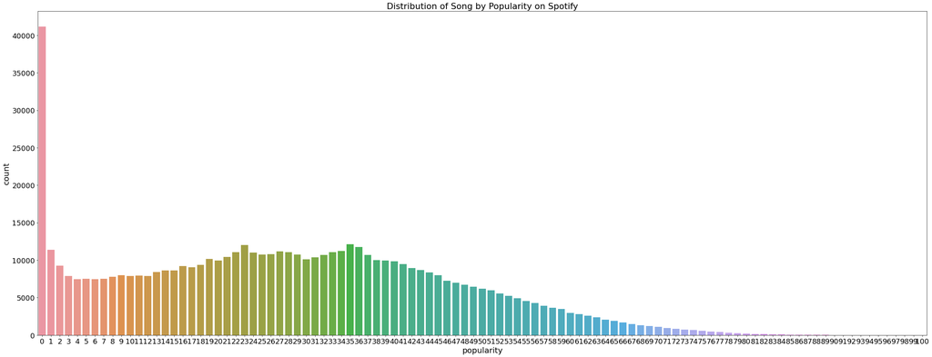

```python
plt.figure(figsize=(40,15))

plt.xlabel("Popularity")
plt.ylabel("Number of Songs")
plt.title("Distribution of Song by Popularity on Spotify")

plt.rc('xtick', labelsize=18)
plt.rc('font', size=18)
plt.rc('axes', labelsize=20)

sns.countplot(data=tracks, x='popularity')    # Plotting with seaborn
```

The majority of songs are at 0 a popularity of 0. In fact, there is only one song with a popularity of 100. Besides the majority at 0, the popularity of songs peaks around 23-35 before gradually decreasing. This is as expected, with a lot of songs not getting recognition, the rest peaking around the same place and very few songs making it to a popularity of 100.

### 3. Exploratory Analysis

Before we do any machine learning, we need to get a better look at our data through some good ol' exploratory analysis. Our goal is to find trends between song popularity and the features we have in our dataframe. One way to do this is to create a correlation matrix for each of the numerical variables. We can quickly visualize what variables may be of interest for the machine learning steps, as well as seeing if there exists any relationships between the variables in the first place. A value closer to 1 means that there is a positive correlation between the two variables, a value of 0 means there is no linear correlation, and a value close to -1 means that there is a negative correlation between the two variables.

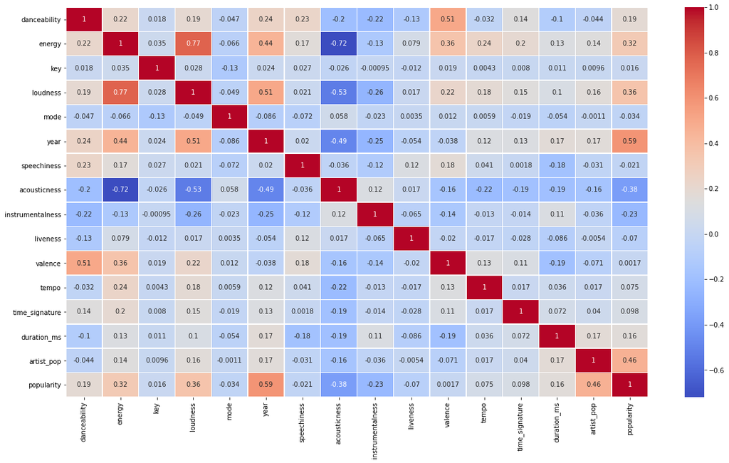

```python
plt.subplots(figsize = (20,11))
sns.heatmap(tracks[[    # these are the variables we are interested in, they have to be numerical to calculate correlation
    'danceability', 'energy', 'key', 'loudness', 'mode', 'year',
       'speechiness', 'acousticness', 'instrumentalness', 'liveness',
       'valence', 'tempo', 'time_signature', 'duration_ms', 'artist_pop', 'popularity'
]].corr(method="spearman"), annot = True, cmap= 'coolwarm', linewidths=.5, annot_kws={"fontsize":10})
```

In the correlation matrix above, we can make a few observations:

1. Loudness and energy are positively correlated, which makes sense given the algorithm to determine energy for spotify includes loudness as a variable.
2. High energy songs are correlated with low acousticness, and vice versa. With what we know about 1, it is unsurprising acousticness and loudness are also negatively correlated.
3. Acousticness and year has a negative correlation, meaning with every year, songs tend to become less acoustic. There might be a large set of acoustic songs from the earlier years in the database skewing the data, or songs are genuinely less likely to be acoustic
4. Loudness and energy are also positively correlated with year, meaning with every year songs tend to get higher energy and louder.

We can take a better look at each of these trends by plotting them individually. Grouping the tracks by popularity and finding the average artist population, year, acousticness, and energy, we can see the general trend which influenced the correlation matrix.

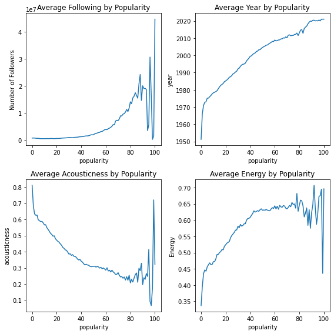

```python
fig, ((ax1,ax2), (ax3,ax4)) = plt.subplots(2,2, figsize=(8,8))

# Group by popularity and average each feature; plot: artist_popularity, year, acousticness, and energy
sns.lineplot(data=tracks.groupby('popularity').agg('mean'), x='popularity', y='artist_pop', ax=ax1)
ax1.set_title('Average Following by Popularity')
ax1.set_ylabel("Number of Followers")

sns.lineplot(data=tracks.groupby('popularity').agg('mean'), x='popularity', y='year', ax=ax2)
ax2.set_title('Average Year by Popularity')

sns.lineplot(data=tracks.groupby('popularity').agg('mean'), x='popularity', y='acousticness', ax=ax3)
ax3.set_title('Average Acousticness by Popularity')

sns.lineplot(data=tracks.groupby('popularity').agg('mean'), x='popularity', y='energy', ax=ax4)
ax4.set_title('Average Energy by Popularity')
ax4.set_ylabel("Energy")

plt.rc('xtick', labelsize=10)
plt.rc('ytick', labelsize=10)
plt.rc('font', size=10)
plt.rc('axes', labelsize=10)

fig.tight_layout()   # make it looks nicer :D
```

All of the graphs fluctuate more when the popularity increases because there are less datapoints to average, so a single song can change the entire average. You can still see the general trends that we observed with the correlation matrix.

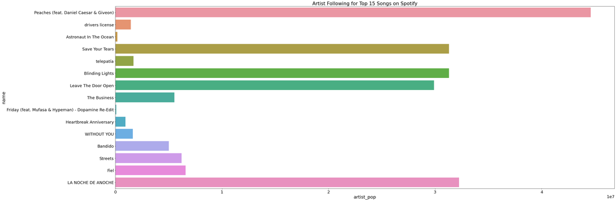

```python
plt.figure(figsize=(40,15))

plt.xlabel("Song Name")
plt.ylabel("Artist Following")
plt.title("Artist Following for Top 15 Songs on Spotify")

plt.rc('xtick', labelsize=18)
plt.rc('font', size=18)
plt.rc('axes', labelsize=20)

sns.barplot(data=tracks.sort_values('popularity', ascending=False).head(15), y='name', x='artist_pop')
```

If we plot the top 15 songs on Spotify and look at the artist following, we can see why the graph fluctuated so much. The artist popularity is incredibly variable with the popularity of the song, even if the trend describes most of the songs before the below an popularity score of 80 (based on the line graph above). Each of these have external reasons which could not be explained with the features we chose, for example drivers license by Olivia Rodrigo was her first song which explains why her following is low.

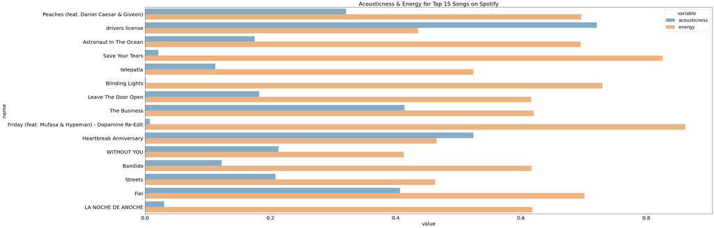

```python
plt.figure(figsize=(40,15))

plt.xlabel("Song Name")
plt.ylabel("Acousticness & Energy")
plt.title("Acousticness & Energy for Top 15 Songs on Spotify")

plt.rc('xtick', labelsize=20)
plt.rc('ytick', labelsize=20)
plt.rc('font', size=18)
plt.rc('axes', labelsize=20)
to_plot = tracks.sort_values('popularity', ascending=False).head(15)[['name',                     # Get the top 15 tracks and
                                                                      'acousticness',             # melt the columns so it is
                                                                      'energy']].melt(['name'])   # name, value, and
                                                                                           # variable (acousticness or energy)
sns.barplot(data=to_plot, y='name', x='value', hue='variable', palette='tab10', alpha=0.6)
```

We can also look at the energy and acousticness by the top 15 songs. Most of them are high energy. The average energy for songs in all of tracks is 0.54 and 10 out of the top 15 songs are greater than this value. As we saw earlier, most songs with high energy also have low acousticness. Overall, even the top 15 songs are quite variable.

### 4. Hypothesis Testing & Machine Learning

#### Studying the correlation of popularity and song

The goal of this project is to create a model which can predict the popularity of a song based on audio features, the year it is released, and the popularity of the artist. For this, our null hypothesis is there is no relationship, and our alternative hypothesis is there exists a relationship. We set our signifcance level, or $\alpha$ to be 0.05.

$ \alpha = 0.05 $

$ H_{0} = $ There is no relation between the audio features or artist popularity and the popularity of the song.

$ H_{a} = $ There exists a relation between the audio features and artist popularity and the popularity of the song.

In other words, we want to create a model which can help us reject the null hypothesis to show the existence of a relationship. For a linear regression model, for a feature to be considered significant, it has to be below our set alpha. And if there exists a relationship, we should be able to model it with machine learning techniques. In this project, we will try four different models:

1. Linear Regression
2. Polynomial Features
3. Decision Trees
4. Random Forest Regressor

### 4.1 Linear Regression Model

The first model is a linear regression (or OLS) model. Linear regression models attempt to fit the data onto a $Y=mx+b$ curve. For us, we have 15 variables we are interested in, making it a $Y=m_{1} x_{1}+m_{2} x_{2}+...+m_{15} x_{15}+b$ curve, with each x representing a feature, each m representing the coefficient for the best fit, and y representing the popularity. In the equation, $Y$ is known as the dependent variable and each of the $x$s are independent or explanatory variables. This is one of the most basic algorithms of machine learning but also incredibly useful.

We will be using statsmodelsapi to get the P values of each coefficient and sklearn's fitting algorithm.

```python
ind = tracks[['danceability', 'energy', 'key', 'loudness', 'mode','year',          # Our independent variables
       'speechiness', 'acousticness', 'instrumentalness', 'liveness',
       'valence', 'tempo', 'time_signature', 'duration_ms', 'artist_pop']]
dep = tracks['popularity']     # Our dependent variables

est = sm.OLS(dep, sm.add_constant(ind)).fit()  # Fit it using statsmodelsapi to get a nicely formatted summary
print(est.summary())
```

```
                            OLS Regression Results
==============================================================================
Dep. Variable:             popularity   R-squared:                       0.416
Model:                            OLS   Adj. R-squared:                  0.416
Method:                 Least Squares   F-statistic:                 2.729e+04
Date:                Mon, 17 May 2021   Prob (F-statistic):               0.00
Time:                        05:34:46   Log-Likelihood:            -2.3355e+06
No. Observations:              575617   AIC:                         4.671e+06
Df Residuals:                  575601   BIC:                         4.671e+06
Df Model:                          15
Covariance Type:            nonrobust
====================================================================================
                       coef    std err          t      P>|t|      [0.025      0.975]
------------------------------------------------------------------------------------
const             -804.7770      2.104   -382.564      0.000    -808.900    -800.654
danceability         4.3443      0.149     29.065      0.000       4.051       4.637
energy              -3.7089      0.156    -23.704      0.000      -4.016      -3.402
key                  0.0137      0.005      2.596      0.009       0.003       0.024
loudness             0.1868      0.006     29.781      0.000       0.174       0.199
mode                 0.5684      0.039     14.397      0.000       0.491       0.646
year                 0.4205      0.001    400.982      0.000       0.418       0.423
speechiness          0.3178      0.115      2.770      0.006       0.093       0.543
acousticness        -4.0422      0.083    -48.763      0.000      -4.205      -3.880
instrumentalness    -5.1318      0.078    -65.779      0.000      -5.285      -4.979
liveness            -3.5414      0.106    -33.394      0.000      -3.749      -3.334
valence             -1.6168      0.098    -16.442      0.000      -1.809      -1.424
tempo               -0.0026      0.001     -3.997      0.000      -0.004      -0.001
time_signature       0.1926      0.040      4.766      0.000       0.113       0.272
duration_ms       9.038e-07   1.56e-07      5.781      0.000    5.97e-07    1.21e-06
artist_pop        6.825e-07   4.46e-09    153.057      0.000    6.74e-07    6.91e-07
==============================================================================
Omnibus:                    16004.027   Durbin-Watson:                   1.164
Prob(Omnibus):                  0.000   Jarque-Bera (JB):            33690.274
Skew:                          -0.172   Prob(JB):                         0.00
Kurtosis:                       4.134   Cond. No.                     4.98e+08
==============================================================================

Notes:
[1] Standard Errors assume that the covariance matrix of the errors is correctly specified.
[2] The condition number is large, 4.98e+08. This might indicate that there are
strong multicollinearity or other numerical problems.
```

So we ran statsmodelsapi to figure out the coefficients of each variable. If we look at the P values for each variable, all of them are below our signficance level which shows that there does exist a relationship between the variables and the popularity of the song. However, the $R^2$ of 42% value at the top - which measures the proportion of variance explained by the independent variables - is not the strongest.

We can also use sklearn's linear regression method with k-Fold cross validation to find the average score across multiple training data sets. Cross validation is particularly helpful with limited data samples. Even though we are definitely not limited with 600k songs, we can use this to quickly see how our model does across multiple sets of training and testing data. The number of folds is the number of groups that will be studied. k=10 is the default for models if you are finding difficulty determining an optimal k value.

```python
regr = linear_model.LinearRegression()                         # create a linear regression model
regr.fit(ind, dep)                                             # fit our data (to graph residuals later)
k_fold = KFold(n_splits=10)                                    # set up k-folds
scores = cross_val_score(regr, ind, dep, cv=k_fold)            # fold ten times

print("Folding 10 times...")
print(f'Average Accuracy: {sum(scores)/len(scores)}')          # average R^2 over ten folds
```

```
Folding 10 times...
Average Accuracy: 0.3743075876760976
```

Bad news, our $R^2$ is quite low with linear regression. We can look at the average residuals to see how we are doing.

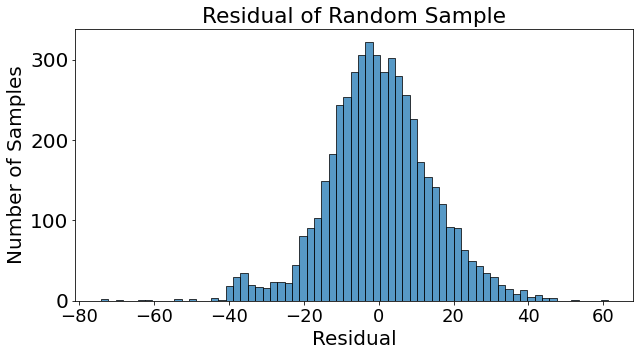

```python
test = tracks.sample(5000)       # sample from tracks
test['residual'] = np.nan

for index,row in test.iterrows():                                                 # for each row, calculate the predicted value
    v = list(row[['danceability', 'energy', 'key', 'loudness', 'mode','year',     # from linear model, then calculate
       'speechiness', 'acousticness', 'instrumentalness', 'liveness',             # the residual
       'valence', 'tempo', 'time_signature', 'duration_ms', 'artist_pop']])
    test.at[index,'residual'] = row['popularity']-regr.predict([v])[0]

plt.figure(figsize=(10,5))
plt.title('Residual of Random Sample')
plt.xlabel("Residual")
plt.ylabel("Number of Samples")

plt.rc('xtick', labelsize=18)
plt.rc('font', size=18)
plt.rc('axes', labelsize=20)

sns.histplot(data=test, x='residual')   # plotting residuals...
```

With a randomly sampled 5000 datapoints, we can see that our residuals are normalized around 0 but have long tails. Some residuals are as large as -80, when the maximum popularity in our training set is 100. Overall, we can be sure that linear regression is not the best model to use.

We can also take a look at what were the most important features according to our model and see how it compares to our exploratory analysis. To do this, we have to standardize the coefficient since everything is in different units. We do this by multiplying the coefficient to the standard deviation of the said variable in the training data.

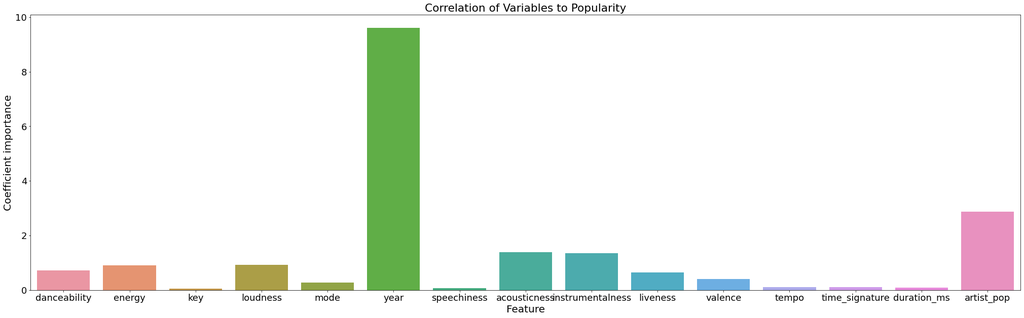

```python
plt.subplots(figsize = (35,10))

plt.title('Correlation of Variables to Popularity')

plt.rc('xtick', labelsize=16)
plt.rc('font', size=18)
plt.rc('axes', labelsize=18)

to_plot = pd.DataFrame([ind.columns, abs(regr.coef_ * X_train.std(axis=0))]).transpose()   # standardizing...
to_plot.columns = ['Feature', 'Coefficient importance']

sns.barplot(data = to_plot, y='Coefficient importance', x='Feature')
```

Like what we saw before, year and artist popularity are the two most important features. Acousticness, energy, instrumentalness also have relatively high importance. On the other hand, key, speechiness, tempo, time signature, and duration make little difference on whether a song becomes popular.

### 4.2 Polynomial Features

Our machine learning was not particularly accurate. No fear, we can try another model. One way to study multiple explanatory variables is to transform our data with PolynomialFeatures. While linear regression was modeled with $Y=m_{1} x_{1}+m_{2} x_{2}+...+m_{15} x_{15}+b$, polynomial features is modeled with $Y=m_{1} x_{1}+...+m_{15} x_{15} + m_{1,2} x_{1} x_{2} +m_{1,3} x_{1} x_{3}+...+ m_{2,3} x_{2} x_{3} +... +m_{15} x_{14} x_{15}+b$ polynomial curve. The point of transforming this data is to study the interactions between two variables. Maybe year and artist popularity separately is not enough to adequately describe a song's popularity but is if you can consider them togehter.

To transform this data, we use sklearn's Polynomial Features. For the code snippet below chose degree 2, which means it will be a second degree polynomial curve, but you can choose a higher degree. Typically, the degree chosen is under 5 because polynomial functions can begin acting in very strange ways. Interaction_only means we only wants the generated interactions, not the squared variables of variable itself - we have it set to true to limit the amount of variables here (my laptop is hissing right now; I know it's not the most professional reason but I have decided to compromise). You may also notice I have only chosen 7 variables. It is entirely because the kernel crashes when I use all the variables, but the choices of variables was based on the coefficient importance that we discovered with linear regression previously. Bias is set to false because we will handle that with LinearRegression.

```python
poly = PolynomialFeatures(degree=2, interaction_only=True, include_bias=False)
X_inter = poly.fit_transform(tracks[['danceability', 'energy', 'loudness','year',   # transform it!
       'acousticness', 'instrumentalness', 'artist_pop']])
```

```python
X_inter = pd.DataFrame(X_inter, columns=columns1 = [
    'danceability', 'energy', 'loudness','year','acousticness', 'instrumentalness', 'artist_pop',
    'dance_energy', 'dance_loudness','dance_year','dance_acousticness', 'dance_instrumentalness', 'dance_artist_pop',
    'energy_loudness','energy_year','energy_acousticness', 'energy_instrumentalness', 'energy_artist_pop',
    'loud_year','loud_acousticness', 'loud_instrumentalness', 'loud_artist_pop',
    'year_acousticness', 'year_instrumentalness', 'year_artist_pop',
    'acoustic_instrumentalness', 'acoustic_artist_pop',
    'instr_artist_pop'
])
```

I labeled each of the variables in the transformed column for a future step. You can see how transform calculates interactions by looking at the order of the variables. For each interaction, the two values are multiplied i.e. dance_energy would just be the danceability * energy.

```python
X_train, X_test, y_train, y_test = train_test_split(X_inter, tracks['popularity'],     # create training and testing data
                                                    test_size=0.33, random_state=42)
regr_poly = linear_model.LinearRegression()
regr_poly.fit(X_train, y_train)  # fit to linear model

print(f'Accuracy (R^2): {regr_poly.score(X_test, y_test)}')                         # calculate R^2 for model
print(f'"Average Error:" {mean_absolute_error(regr_poly.predict(X_test), y_test)}') # calculate average error with sklearn
```

```
Accuracy (R^2): 0.44023333340291193
"Average Error:" 10.554256481589123
```

Our calculated R^2 is already better (the previous was 0.3743)! Of course, this one wasn't averaged over multiple tests but transforming our data has helped in general. Our mean absolute error - the average distance off our predicted value is from the actual value - is still relatively high at 10.5. This is still not the best model, but we will look at 2 more options that are not linear regression.

But first, we can look at the coefficient importance for the new model:

```python
pd.DataFrame(
    abs(regr_poly.coef_ *
    X_train.std(axis=0)),
    columns=['Coefficient importance'], index=X_inter.columns
).sort_values('Coefficient importance', ascending=False).head(5)      # five largest coefficient importance
```

|  | Coefficient importance |
| --- | --- |
| artist_pop | 178.955815 |
| year_artist_pop | 176.062595 |
| energy_year | 128.227455 |
| energy | 125.236133 |
| acousticness | 123.120842 |

The top 5 most important features for predicting a song's popularity are the artist's popularity and the transformed feature for year and artist popularity combined, which even ranks above year alone. This makes sense - think about it like this: recent songs do not all necessarily do well, and not all songs by popular artists are currently trending (especially if they are old songs). But new songs by popular artists are very popular. Next is energy and year, followed by energy, then acousticness.

```python
pd.DataFrame(
    abs(regr_poly.coef_ *
    X_train.std(axis=0)),
    columns=['Coefficient importance'], index=X_inter.columns
).sort_values('Coefficient importance', ascending=False).tail(3)      # three smallest coefficient importance
```

|  | Coefficient importance |
| --- | --- |
| acoustic_artist_pop | 0.168521 |
| energy_loudness | 0.080466 |
| instr_artist_pop | 0.004173 |

Looking at the three least important features: acoustic and artist popularity, energy and loudness of song, and instrumentalness and artist popularity.

### 4.3 Decision Tree

Okay, so transforming the data still got us a $R^2$ below 0.5. What other models can we try? Decision trees basically ask a series of yes/no - true/false - if/else questions to reach a classification as quickly as possible. At each point in the tree, the question narrows the possible values until we are fairly confident in our answer. When we test against the decision tree, it estimates based on the data used for training. For this part, we will be implementing decision trees with sklearn. Because we are trying to estimate a value (popularity) and not classifying it, and we are doing supervised learning, we will be using DecisionTreeRegressor.

One thing decision trees tend to have an issue with is overfitting. You can see it with our initial run of the code:

```python
X_train, X_test, y_train, y_test = train_test_split(ind, tracks['popularity'], test_size=0.33)
tree = DecisionTreeRegressor()   # decision tree
tree.fit(X_train, y_train)       # fit

print("Fitting on a decision tree model...")
print(f'"Accuracy on training set:" {tree.score(X_train, y_train)}')  # R^2 of training set
print(f'"Accuracy on test set:" {tree.score(X_test, y_test)}')        # R^2 of testing set
```

```
Fitting on a decision tree model...
"Accuracy on training set:" 0.9947992129729838
"Accuracy on test set:" 0.3502475462152419
```

The score on the training set is nearly 1 while the score for the testing set is around 0.35 - lower than our initial linear regression model. We can try to fix this issue by defining hyperparameters on the decision tree. One of these is the maximum leaf nodes which can control overfitting. High maximum values can lead to overfitting, so we want a choose a value carefully. Additionally, at a certain point, increasing the maximum leaf nodes no longer increases our score. The following code calculates the lowest maximum leaf node that no longer produces a 0.001 increase in the score.

```python
to_plot = []  # to be used later
prev = 0

for i in range(2,5000, 20):                             # for each possible max_leaf_nodes, from min 2 to 5000 in steps of 20
    tree = DecisionTreeRegressor(max_leaf_nodes=i)
    tree.fit(X_train, y_train)
    curr = tree.score(X_test, y_test)                   # calculate the R^2 of the model. When the current one is
    to_plot.append([i, curr])
    if curr-prev<0.001:                                 # less than 0.1% better than the previous max_leaf_nodes
        print (i)                                       # stop and print the value
        break
    else:
        prev = curr                                     # if it's not smaller, keep going
```

```
302
```

We can also see how maximum leaf nodes affects the $R^2$ of the testing set.

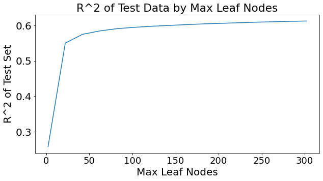

```python
plt.figure(figsize=(10,5))
plt.title('R^2 of Test Data by Max Leaf Nodes')
plt.xlabel("Max Leaf Nodes")
plt.ylabel("R^2 of Test Set")

sns.lineplot(data=pd.DataFrame(to_plot, columns=['Max Leaf Nodes', 'R^2']), x='Max Leaf Nodes', y='R^2')
```

So let's run this again with our maximum leaf nodes:

```python
X_train, X_test, y_train, y_test = train_test_split(ind, tracks['popularity'], test_size=0.33)
tree = DecisionTreeRegressor(max_depth=12, max_leaf_nodes=302)   # max depth was found in a similar fashion
tree.fit(X_train, y_train)

print(f'"Accuracy on training set:" {tree.score(X_train, y_train)}')             # R^2 of training set
print(f'"Accuracy on test set:" {tree.score(X_test, y_test)}')                   # R^2 of testing set
print(f'"Error on test set:" {mean_absolute_error(tree.predict(X_test), y_test)}')
```

```
"Accuracy on training set:" 0.6188234609591337
"Accuracy on test set:" 0.6106647212127783
"Error on test set:" 8.469941305521182
```

Our score has improved! By tuning the hyperparameters, we can get a better prediction on the testing set. 0.61 is not the best but at this point, it might be the fact that you can not easily predict a song's popularity. Humans don't necessarily follow algorithms well. But we can try one more model.

### 4.4 Random Forest Regressor

For our final model, we will be looking at the random forests. Random forests are made by building a bunch of decision trees and combining the predictions for a more robust result. They are random because they use random sampling when choosing the training observations for each tree and when splitting nodes. Random forest is best for high variance and large datasets which describes our dataset!

Unfortunately, we are doing the test on a sample of 10,000 songs from the database instead of the full one for this. Random forests do require a bit more computational power than my laptop can handle but with 10,000 we can still observe the results. To use random forest, we will be using sklearn's RandomForestRegressor.

```python
test = tracks.sample(10000)  # sample 10,000 songs from the entirety of tracks

X_train, X_test, y_train, y_test = train_test_split(test[[
    'danceability', 'energy', 'key', 'loudness', 'mode','year',
       'speechiness', 'acousticness', 'instrumentalness', 'liveness',
       'valence', 'tempo', 'time_signature', 'duration_ms','artist_pop'
]], test['popularity'], test_size=0.33)

rf = RandomForestRegressor(random_state=0)    # random forest with default values
rf.fit(X_train, y_train)                      # fit the data

print(f'"Accuracy on test set:" {rf.score(X_test, y_test)}')                             # R^2 of testing set
print(f'"Error on test set:" {mean_absolute_error(rf.predict(X_test), y_test)}')         # MAE of testing set
```

```
"Accuracy on test set:" 0.5937134638363091
"Error on test set:" 8.711834646464647
```

Ok initial run - not bad. It's worse than our decision tree which may be from the limited sample data. But with only 10,000 songs, it has a score of 0.59. Compared to our original 0.37 from linear regression, we are doing better! But we can do the same thing we did with decision trees here and try to figure out a better set of hyperparameters with the RandomizedSearchCV:

```python
random_grid = {'n_estimators': range(100,1000,200),          # n estimators is the number of trees created, 100 is default
               'max_features': ['auto','sqrt','log2'],       # the number of features the model will consider, auto is all
               'max_depth': range(10,100,20),                # maximum depth of any tree
               'min_samples_split': [2,5,10],                # minimum number of samples to split node further
               'min_samples_leaf': [2,10,16,24]}             # minimum number of samples to fit in each leaf

rf = RandomForestRegressor()
rf_random = RandomizedSearchCV(estimator = rf, param_distributions = random_grid,
                               n_iter = 100, cv = 2, verbose=2, random_state=42, n_jobs = -1) # 100 random combinations from
                                                                                              # the above grid, each done twice
rf_random.fit(X_train, y_train) # search
rf_random.best_params_          # print best parameters
```

```
Fitting 2 folds for each of 100 candidates, totalling 200 fits
```

```
{'n_estimators': 900,
 'min_samples_split': 5,
 'min_samples_leaf': 2,
 'max_features': 'auto',
 'max_depth': 70}
```

Results are in: the best option from above was a combination of 900 trees, minimum sample splitting of 5, minimum sample leafs at 2, max features at auto, and max depth at 70.

```python
clf = RandomForestRegressor(n_estimators=900, min_samples_split=5, min_samples_leaf=2, max_features='auto',
                            max_depth=70, random_state=0)     # running again with "optimal" parameters

clf.fit(X_train, y_train)

print(f'"Accuracy on test set:" {clf.score(X_test, y_test)}')                         # R^2 of testing set
print(f'"Error on test set:" {mean_absolute_error(clf.predict(X_test), y_test)}')     # MAE of testing set
```

```
"Accuracy on test set:" 0.5989792791967378
"Error on test set:" 8.632886519413885
```

Running it again, we have a small improvement of a score of 0.005, and about 0.1 decrease in error.

### 5. Conclusion

Let's compare the final models and how well we did:

[output not shown]

The decision tree did the best here, though our random forest was done with a limited set of data instead. However, even at our best, the model's score was 0.61 with a mean absolute error of 8.47 when figuring out the popularity of a song.

#### So now what?

Humans listen to a lot of music, sometimes randomly, sometimes with external factors that weren't measured here, and in unpredictable ways. Sometimes we go completely 180 from what we like to a completely different genre. There are factors which contribute to a song's popularity - artist popularity, how recently it was released, and the energy of the song. Apparently popular music at the moment is trending to be less acoustic and higher energy. This is in no way a rule though, with the second most popular song on our list having a high acoustic value and low energy value. Maybe music does not have easy rules. There's no such thing as the best song or one that will appeal to everyone. Maybe we should just aim to write the music we want to hear.

Though, this is kind a disappointing ending for machine learning tutorial. So here's a really small bonus with sklearn's nearest neighbor algorithm:

### Bonus: Song Recommendation

I have no way of testing if these are good predictions with the current data but you can run it yourself and decide! The idea is simple: sklearn's NearestNeighbors takes a bunch of data and calculates the distance from each other. When you call on it to predict a value, it gives you the k-nearest neighbors for a self-defined k. Here, I chose k=10 and calculated distance on energy, valence, speechiness, and popularity of the song. With k-nearest neighbors, too many dimensions makes distance calculations more difficult, so I stuck with 4 that I considered important when choosing new songs.

The first result returned will always be the song you are searching itself, followed by 9 of its nearest neighbors.

```python
def recomendation(neigh, song_name, artist):    # get the recommendation of a song

    result = []

    match = tracks[tracks['name']==song_name]                 # get all of the tracks that match the song_name exactly
    match = match[match['artists'].str.contains(artist)]      # from there, look for songs which contain the artist name

    if len(match) == 0: # if there are no results, no songs could be found in the dataset
        print ("Sorry, there were no songs with that name and artist in the database.")
        return result

    song = match.sort_values('popularity', ascending=False).head(1)  # if there are multiple matches, use the most popular
    distance, indices = neigh.kneighbors(song[['energy','valence', 'speechiness', 'popularity']])  # get the nearest neighbors
                                                                                        # distance is the calculated distance
    count = 0                                                                           # from target and indices is the index
    for i in indices[0]:                                                                 # the value is on
        rec = tracks[tracks['num']==i].head(1)  # index is along 'num'
        result.append([list(rec['name'])[0], list(rec['artists'])[0], distance[0][count]])   # for each index, append the song
        count += 1

    return result

tracks['num'] = range(0,len(tracks))
neigh = NearestNeighbors(n_neighbors=10)   # initialize nearest neighbors
neigh.fit(tracks[['energy','valence', 'speechiness', 'popularity']])  # fit to the variables

pd.DataFrame(recomendation(neigh, 'Don\'t Stop Believin\'', 'Journey' ))  # recommend me a song!!
```

|  | 0 | 1 | 2 |
| --- | --- | --- | --- |
| 0 | Don't Stop Believin' | ['Journey'] | 0.000000 |
| 1 | Ride | ['Twenty One Pilots'] | 0.062753 |
| 2 | Yo Perreo Sola | ['Bad Bunny'] | 0.070166 |
| 3 | Can't Feel My Face | ['The Weeknd'] | 0.072391 |
| 4 | Christian Dior | ['Jhay Cortez'] | 0.076159 |
| 5 | Patience (feat. YUNGBLUD & Polo G) | ['KSI', 'YUNGBLUD', 'Polo G'] | 0.083533 |
| 6 | The Chain - 2004 Remaster | ['Fleetwood Mac'] | 0.085731 |
| 7 | Drag Me Down | ['One Direction'] | 0.092663 |
| 8 | Demons | ['Imagine Dragons'] | 0.094115 |
| 9 | Can I Call You Tonight? | ['Dayglow'] | 0.095302 |

### Resources & Further Reading

Interested in reading more, even after this entire tutorial? Here are some of my favorite articles and links:

- [New York Times "The Culture Warped Pop, for Good"](https://www.nytimes.com/interactive/2021/03/14/opinion/pop-music-songwriting.html) This is a really cool interactive story about how pop music has been changing over time. I read it when it first released and I still think about it. It's definitely worth checking out if you are interested in how pop music has changed over time!
- [How Spotify themselves are using machine learning](https://outsideinsight.com/insights/how-ai-helps-spotify-win-in-the-music-streaming-world/)
- Useful links for learning about [Random Forests](https://gdcoder.com/random-forest-regressor-explained-in-depth/), [Decision Trees](https://gdcoder.com/decision-tree-regressor-explained-in-depth/), and tuning of [parameters](https://towardsdatascience.com/hyperparameter-tuning-the-random-forest-in-python-using-scikit-learn-28d2aa77dd74)